# Assignment 4

## Submit as an HTML file

Print your name and Emory ID below

```python
print("Angelica")
print(2672070)
```

```
Angelica
2672070
```

Importing relevant libraries (matplotlib, NumPy)

```python
import matplotlib.pyplot as plt
import numpy as np
```

### a) For-loops and Conditional Statements

Using the list of test scores below, create a new list of students who made the honor roll (students with a grade greater than or equal to 90).

- Create a second list containing student names, where each name directly corresponds to a score in `test_scores`.
- Use a for loop to iterate through both lists and store the names and scores of students who made the honor roll in two new lists:
  - `honor_roll_names`: The names of students who made the honor roll.
  - `honor_roll_scores`: The scores of students who made the honor roll.
- Print the results of both lists.

```python
test_scores = [85, 92, 88, 96, 75, 91, 89, 98, 72, 90]
student_names = ["Alice", "Bob", "Charlie", "David", "Eve",
                 "Frank", "Grace", "Hannah", "Ivy", "Jack"]
```

```python
# Write your answer here
test_scores = [85, 92, 88, 96, 75, 91, 89, 98, 72, 90]
student_names = ["Alice", "Bob", "Charlie", "David", "Eve",
                 "Frank", "Grace", "Hannah", "Ivy", "Jack"]

honor_roll_names = []
honor_roll_scores = []

for i in range(len(test_scores)):
    if test_scores[i] >= 90:
        honor_roll_names.append(student_names[i])
        honor_roll_scores.append(test_scores[i])

print("Honor Roll Names:", honor_roll_names)
print("Honor Roll Scores:", honor_roll_scores)
```

```
Honor Roll Names: ['Bob', 'David', 'Frank', 'Hannah', 'Jack']
Honor Roll Scores: [92, 96, 91, 98, 90]
```

### b) Follow-up to Part (a)

Using NumPy, perform the following operations on the `honor_roll_scores` list:

- Count and print the total number of students who made the honor roll using `np.size()`.
- Calculate and print the average score of the students on the honor roll using `np.mean()`.
- Determine and print the highest score from the honor roll using `np.max()`.
- Print the total number of students, average score and the highest score found.

#### Hint:

First convert the scores array to a NumPy array.  
Use the following NumPy functions where necessary:

- [`np.size()`](https://numpy.org/doc/stable/reference/generated/numpy.size.html)
- [`np.mean()`](https://numpy.org/doc/stable/reference/generated/numpy.mean.html)
- [`np.max()`](https://numpy.org/doc/stable/reference/generated/numpy.amax.html)

```python
#Write your answer here
honor_roll_scores_array = np.array(honor_roll_scores)

student_size = np.size(honor_roll_scores_array)
average_score = np.mean(honor_roll_scores_array)
highest_score = np.max(honor_roll_scores_array)

print("Total Students on Honor Roll:", student_size)
print("Average Score of Honor Roll:", average_score)
print("Highest Score on Honor Roll:", highest_score)
```

```
Total Students on Honor Roll: 5
Average Score of Honor Roll: 93.4
Highest Score on Honor Roll: 98
```

c) For-loops + plotting

- Create an array of x-values with all the integers between 1 and 15.
- Create a vector `vec_y1` where each element is computed from the formula  
  $ y_1 = 3x^3 + 5x^2 - x$.
- Create a vector `vec_y2` where each element is computed from the formula  
  $ y_2 = x^4 - 6x^2 + 2x$.
- Create an object `list_vectors` with elements `vec_y1` and `vec_y2`.
- Create a for-loop that goes through each element of `list_vectors` and plots each list of $y$ values against $x$.

Note: The final output should be a 2-dimensional scatter plot with two sets of points, with the $y_1$ and $y_2$ on the vertical axis, and the $x$ values  
on the horizontal axis. Remember to always label the axes and add a title to the plot to make it look more professional.

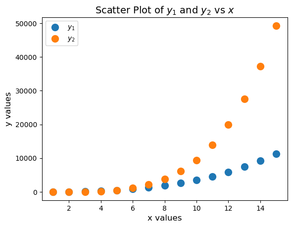

```python
#Write your answer here
import numpy as np
import matplotlib.pyplot as plt

x = np.arange(1, 16)

vec_y1 = 3*x**3 + 5*x**2 - x
vec_y2 = x**4 - 6*x**2 + 2*x

list_vectors = [vec_y1, vec_y2]


for vec in list_vectors:
    plt.scatter(x, vec, label=f'${"y_1" if vec is vec_y1 else "y_2"}$', s=100)

plt.xlabel('x values', fontsize=12)
plt.ylabel('y values', fontsize=12)
plt.title('Scatter Plot of $y_1$ and $y_2$ vs $x$', fontsize=14)
plt.legend()

plt.show()
```

### d) Average grades, learn how to use zip()

- Below, write a chunk of code that prints out the average grade for each student. The names and grades are given in the lists below.
- The program should print the student's name and their average grade, formatted like this:

```
Alice's average grade: 87.67
Bob's average grade: 89.0
Charlie's average grade: 89.33
David's average grade: 96.0
Eve's average grade: 78.33
```

Hints/Tips:

- You can use zip() to iterate through multiple lists at once, making the code cleaner.
- You can learn more about zip() here: [Python zip() Function](https://www.geeksforgeeks.org/zip-in-python/)
- When you print the statements out, you can cast the average grade to a string using str()
- Ignore the rounding, the number of decimal places in each calculated average grade does not matter.

```python
student_names = ["Alice", "Bob", "Charlie", "David", "Eve"]
grades1 = [85, 92, 88, 96, 75]
grades2 = [90, 80, 89, 94, 82]
grades3 = [88, 95, 91, 98, 78]
```

```python
# Write your answer here

students = ['Alice', 'Bob', 'Charlie', 'David', 'Eve']
grades = [
    [85, 90, 88],
    [92, 80, 95],
    [88, 89, 91],
    [96, 94, 98],
    [75, 82, 78]
]
#average_grade = sum(grades_list) / len(grades_list)
#print(f"{student}'s average grade: {average_grade}")
#grade_list = zip(students, grades)
#res = zip(students, grades)
#average_grade = sum(grade_list) / len(grade_list)

for student, grade_list in zip(students, grades):
    average_grade = sum(grade_list) / len(grade_list)
    print(f"{student}'s average grade: {average_grade}")
```

```
Alice's average grade: 87.66666666666667
Bob's average grade: 89.0
Charlie's average grade: 89.33333333333333
David's average grade: 96.0
Eve's average grade: 78.33333333333333
```

### e) Simulating and visualizing

In order to recieve full credit, please answer the first question in the markdown cell below the code. Answer the second question by making your changes to the code chunk below.

- How does the sample size and the number of simulations affect the distribution of the sample means in the code below?
- Generate and plot multiple histograms with different sample sizes:
  - Create at three histograms: one with a small sample size (e.g., 10), one with a medium sample size (e.g., 100), and one with a large sample size (e.g., 1000).
  - Make sure that the number of simulations is the same for all three (set the number of simulations to 250)

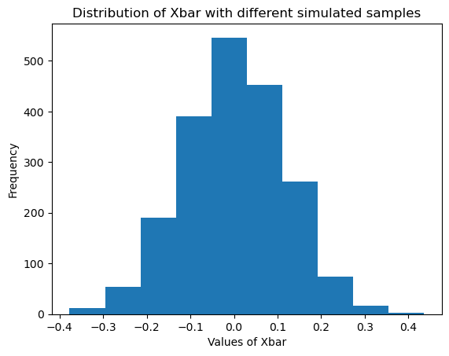

```python
#Original Code
num_simulations = 2000
sample_size     = 100

vec_xbar = [None] * num_simulations

for iteration in range(num_simulations):
    vec_unif  = np.random.uniform(low = -2, high=2, size = sample_size)
    vec_xbar[iteration] = vec_unif.mean()

vec_xbar

plt.hist(vec_xbar)
plt.title("Distribution of Xbar with different simulated samples")
plt.ylabel("Frequency")
plt.xlabel("Values of Xbar")
plt.show()
```

### Write your answer in this cell

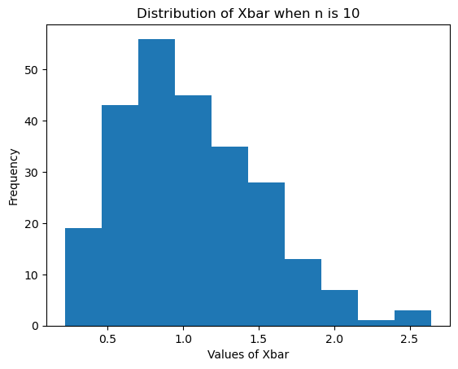

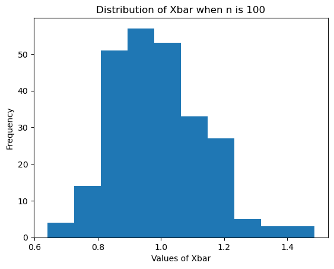

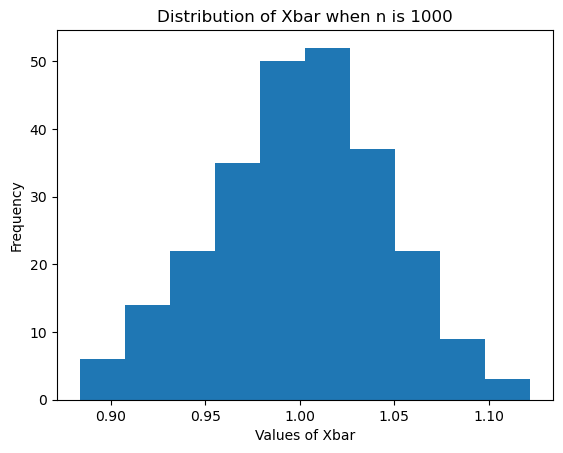

```python
num_simulations = 250
sample_size_list = [10,100,1000]

for sample_size in sample_size_list:

    # The following command a vector null values, of length "num_simulations"
    vec_xbar = [None] * num_simulations

    for iteration in range(num_simulations):
            vec_chisqr  = np.random.chisquare(df = 1, size = sample_size)
            vec_xbar[iteration] = vec_chisqr.mean()
    plt.hist(vec_xbar)
    plt.title("Distribution of Xbar when n is " + str(sample_size))
    plt.ylabel("Frequency")
    plt.xlabel("Values of Xbar")
    plt.show()
```

[figure not shown]

```python
#Small sample (write your answer here)
# With a lower sample size and a larger number of simulations, the distribution of the sample mean is normal
#Small Sample size of 10
num_simulations = 250
sample_size     = 10

vec_xbar = [None] * num_simulations

for iteration in range(num_simulations):
    vec_unif  = np.random.uniform(low = -2, high=2, size = sample_size)
    vec_xbar[iteration] = vec_unif.mean()

vec_xbar

plt.hist(vec_xbar)
plt.title("Distribution of Xbar with Sample Size 10")
plt.ylabel("Frequency")
plt.xlabel("Values of Xbar")
plt.show()
```

[figure not shown]

```python
#Medium sample (write your answer here)
# With a medium sample size and a larger number of simulations, the distribution of the sample mean is not normal with a dip in the center
num_simulations = 250
sample_size     = 100

vec_xbar = [None] * num_simulations

for iteration in range(num_simulations):
    vec_unif  = np.random.uniform(low = -2, high=2, size = sample_size)
    vec_xbar[iteration] = vec_unif.mean()

vec_xbar

plt.hist(vec_xbar)
plt.title("Distribution of Xbar with Sample Size 100")
plt.ylabel("Frequency")
plt.xlabel("Values of Xbar")
plt.show()
```

[figure not shown]

```python
#Large sample (write your answer here)
# With a larger sample size and a larger number of simulations, the distribution of the sample mean is normal
num_simulations = 250
sample_size     = 1000

vec_xbar = [None] * num_simulations

for iteration in range(num_simulations):
    vec_unif  = np.random.uniform(low = -2, high=2, size = sample_size)
    vec_xbar[iteration] = vec_unif.mean()

vec_xbar

plt.hist(vec_xbar)
plt.title("Distribution of Xbar with Sample Size 1000")
plt.ylabel("Frequency")
plt.xlabel("Values of Xbar")
plt.show()
```